# S1.9

#### 1.4.2. Pooled Model

```r
m.final.pooled <- rma.mv(TE ~ 1 +  1,
                   V = VCV,
                   data = df_ma,
                   sparse = TRUE,
                     random = ~ 1 | Study/UniqueCode)
summary(m.final.pooled)
```

```
##
## Multivariate Meta-Analysis Model (k = 238; method: REML)
##
##   logLik  Deviance       AIC       BIC      AICc
## -93.7410  187.4820  193.4820  203.8862  193.5850
##
## Variance Components:
##
##             estim    sqrt  nlvls  fixed            factor
## sigma^2.1  0.0682  0.2612     37     no             Study
## sigma^2.2  0.0349  0.1869    238     no  Study/UniqueCode
##
## Model Results:
##
## estimate      se     zval    pval    ci.lb   ci.ub
##  -0.0040  0.0530  -0.0764  0.9391  -0.1079  0.0998
##
## ---
## Signif. codes:  0 '***' 0.001 '**' 0.01 '*' 0.05 '.' 0.1 ' ' 1
```

```r
# Calculation of i2 values using code from metafor project: https://www.metafor-project.org/doku.php/tips:i2_multilevel_multivariate
res <- m.final.pooled
W <- diag(1/res$vi)
X <- model.matrix(res)
P <- W - W %*% X %*% solve(t(X) %*% W %*% X) %*% t(X) %*% W
100 * sum(res$sigma2) / (sum(res$sigma2) + (res$k-res$p)/sum(diag(P))) # total I2
```

```
## [1] 99.99973
```

```r
100 * res$sigma2 / (sum(res$sigma2) + (res$k-res$p)/sum(diag(P))) # between and within I2
```

```
## [1] 66.15357 33.84615
```

```r
100 - (67.69537 + 32.30437) # I2 due to sampling error
```

```
## [1] 0.00026
```

#### 1.4.3. Driving Process Model

```r
# rho 0.29, moderator
VCV <- vcalc(vi = se.TE,
             cluster = Study,
             rho = 0.29,
             obs = TE,
             data = df_ma)
m.final <- rma.mv(TE ~ 1 +  Treatment_Thematic,
                   V = VCV,
                   data = df_ma,
                   sparse = TRUE,
                     random = ~ 1 | Study/UniqueCode)
summary(m.final)
```

```
##
## Multivariate Meta-Analysis Model (k = 237; method: REML)
##
##   logLik  Deviance       AIC       BIC      AICc
## -85.7155  171.4311  191.4311  225.7683  192.4403
##
## Variance Components:
##
##             estim    sqrt  nlvls  fixed            factor
## sigma^2.1  0.0606  0.2461     36     no             Study
## sigma^2.2  0.0349  0.1868    237     no  Study/UniqueCode
##
## Test of Moderators (coefficients 2:8):
## QM(df = 7) = 10.1018, p-val = 0.1829
##
## Model Results:
##
##                                                                      estimate
## intrcpt                                                               -0.2485
## Treatment_ThematicSoil / substrate                                     0.2546
## Treatment_ThematicGrazing                                              0.3989
## Treatment_ThematicFire + Grazing                                       0.3178
## Treatment_ThematicFire + Exotic species planted, fertiliser applied    0.2485
## Treatment_ThematicFire + Climate change                                0.5340
## Treatment_ThematicFire                                                 0.1617
## Treatment_ThematicClimate change                                       0.4002
##                                                                          se
## intrcpt                                                              0.1195
## Treatment_ThematicSoil / substrate                                   0.2356
## Treatment_ThematicGrazing                                            0.1524
## Treatment_ThematicFire + Grazing                                     0.2135
## Treatment_ThematicFire + Exotic species planted, fertiliser applied  0.5150
## Treatment_ThematicFire + Climate change                              0.2850
## Treatment_ThematicFire                                               0.1495
## Treatment_ThematicClimate change                                     0.1729
##                                                                         zval
## intrcpt                                                              -2.0798
## Treatment_ThematicSoil / substrate                                    1.0808
## Treatment_ThematicGrazing                                             2.6164
## Treatment_ThematicFire + Grazing                                      1.4887
```

[output cut: 28 more lines]

```
## Treatment_ThematicFire + Climate change                               1.0926
## Treatment_ThematicFire                                                0.4547
## Treatment_ThematicClimate change                                      0.7390
##
## intrcpt                                                               *
## Treatment_ThematicSoil / substrate
## Treatment_ThematicGrazing                                            **
## Treatment_ThematicFire + Grazing
## Treatment_ThematicFire + Exotic species planted, fertiliser applied
## Treatment_ThematicFire + Climate change                               .
## Treatment_ThematicFire
## Treatment_ThematicClimate change                                      *
##
## ---
## Signif. codes:  0 '***' 0.001 '**' 0.01 '*' 0.05 '.' 0.1 ' ' 1
```

```r
# Calculation of i2 values using code from metafor project: https://www.metafor-project.org/doku.php/tips:i2_multilevel_multivariate
summary(m.final)
```

```
##
## Multivariate Meta-Analysis Model (k = 237; method: REML)
##
##   logLik  Deviance       AIC       BIC      AICc
## -85.7155  171.4311  191.4311  225.7683  192.4403
##
## Variance Components:
##
##             estim    sqrt  nlvls  fixed            factor
## sigma^2.1  0.0606  0.2461     36     no             Study
## sigma^2.2  0.0349  0.1868    237     no  Study/UniqueCode
##
## Test of Moderators (coefficients 2:8):
## QM(df = 7) = 10.1018, p-val = 0.1829
##
## Model Results:
##
##                                                                      estimate
## intrcpt                                                               -0.2485
## Treatment_ThematicSoil / substrate                                     0.2546
## Treatment_ThematicGrazing                                              0.3989
## Treatment_ThematicFire + Grazing                                       0.3178
## Treatment_ThematicFire + Exotic species planted, fertiliser applied    0.2485
## Treatment_ThematicFire + Climate change                                0.5340
## Treatment_ThematicFire                                                 0.1617
## Treatment_ThematicClimate change                                       0.4002
##                                                                          se
## intrcpt                                                              0.1195
## Treatment_ThematicSoil / substrate                                   0.2356
## Treatment_ThematicGrazing                                            0.1524
## Treatment_ThematicFire + Grazing                                     0.2135
## Treatment_ThematicFire + Exotic species planted, fertiliser applied  0.5150
## Treatment_ThematicFire + Climate change                              0.2850
## Treatment_ThematicFire                                               0.1495
## Treatment_ThematicClimate change                                     0.1729
##                                                                         zval
## intrcpt                                                              -2.0798
## Treatment_ThematicSoil / substrate                                    1.0808
## Treatment_ThematicGrazing                                             2.6164
## Treatment_ThematicFire + Grazing                                      1.4887
```

[output cut: 28 more lines]

```
## Treatment_ThematicFire + Climate change                               1.0926
## Treatment_ThematicFire                                                0.4547
## Treatment_ThematicClimate change                                      0.7390
##
## intrcpt                                                               *
## Treatment_ThematicSoil / substrate
## Treatment_ThematicGrazing                                            **
## Treatment_ThematicFire + Grazing
## Treatment_ThematicFire + Exotic species planted, fertiliser applied
## Treatment_ThematicFire + Climate change                               .
## Treatment_ThematicFire
## Treatment_ThematicClimate change                                      *
##
## ---
## Signif. codes:  0 '***' 0.001 '**' 0.01 '*' 0.05 '.' 0.1 ' ' 1
```

```r
res <- m.final
W <- diag(1/res$vi)
X <- model.matrix(res)
P <- W - W %*% X %*% solve(t(X) %*% W %*% X) %*% t(X) %*% W
100 * sum(res$sigma2) / (sum(res$sigma2) + (res$k-res$p)/sum(diag(P))) # total I2
```

```
## [1] 99.99956
```

```r
100 * res$sigma2 / (sum(res$sigma2) + (res$k-res$p)/sum(diag(P))) # between and within I2
```

```
## [1] 63.44142 36.55814
```

```r
100 - (62.61131+37.38824) # I2 due to sampling error
```

```
## [1] 0.00045
```

Figure 7. Orchard plot of Pooled Model, and Driving Process Model. Following tutorial buy Daniel Noble, here: https://daniel1noble.github.io/orchaRd/

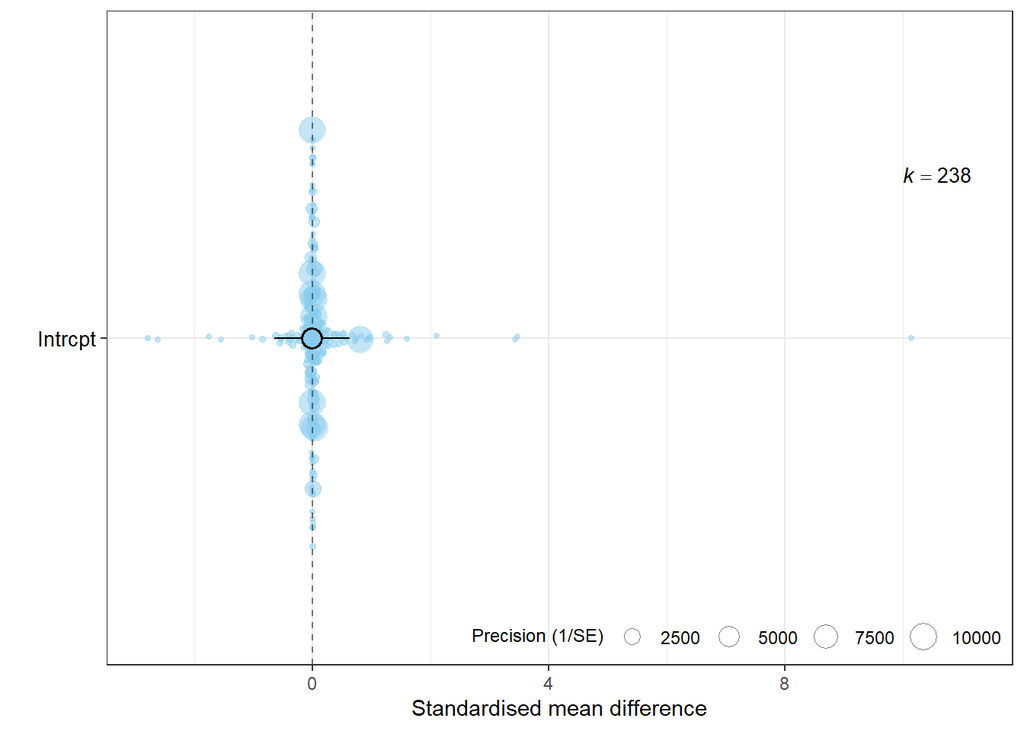

```r
# 1. Visualising all results using pooled model
model_results_0 <- orchaRd::mod_results(m.final.pooled, mod = "1", at = NULL, group = "UniqueCode")
p.all <- orchaRd::orchard_plot(model_results_0, mod = "1", group = "StudyNo", xlab = "Standardised mean difference",
                             angle = 0, g = FALSE,
                             transfm = "none", twig.size = 0.5, trunk.size = 1) # All effect sizes

# 2. Visualising by biological level of organisation (Response.Level)
# Subgroup, all disturbance by response level
# UniqueCode (study within each record) is non-independence. The m.final found disturbance effects, however,
# we could fit Response.Level (population level) as a fixed effect and explore result with Orchard Plot.
# See e.g. 4.3. for this: https://daniel1noble.github.io/orchaRd/
m.final.pooled.poplevel <- rma.mv(TE ~ 1 +  Response.Level,
                   V = VCV,
                   data = df_ma,
                   sparse = TRUE,
                     random = ~ 1 | Study/UniqueCode) # Redo model to allow for
model_results <- orchaRd::mod_results(m.final.pooled.poplevel, mod = "Response.Level", group = "UniqueCode")

p.all.poplevel <- orchaRd::orchard_plot(model_results , mod = "Response.Level", xlab = "Standardised mean difference")

p.all
```

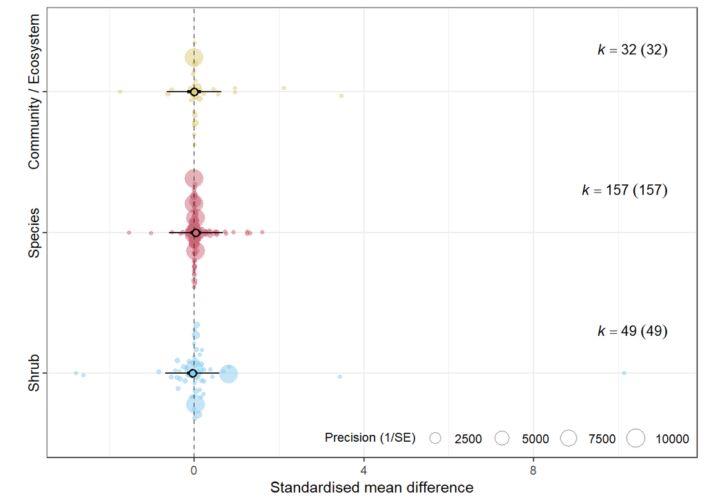

```r
p.all.poplevel
```

```r
# 2. Visualising results specific to disturbance
I2 <- orchaRd::i2_ml(m.final)
I2
```

```
##            I2_Total            I2_Study I2_Study/UniqueCode
##            99.99970            63.44151            36.55819
```

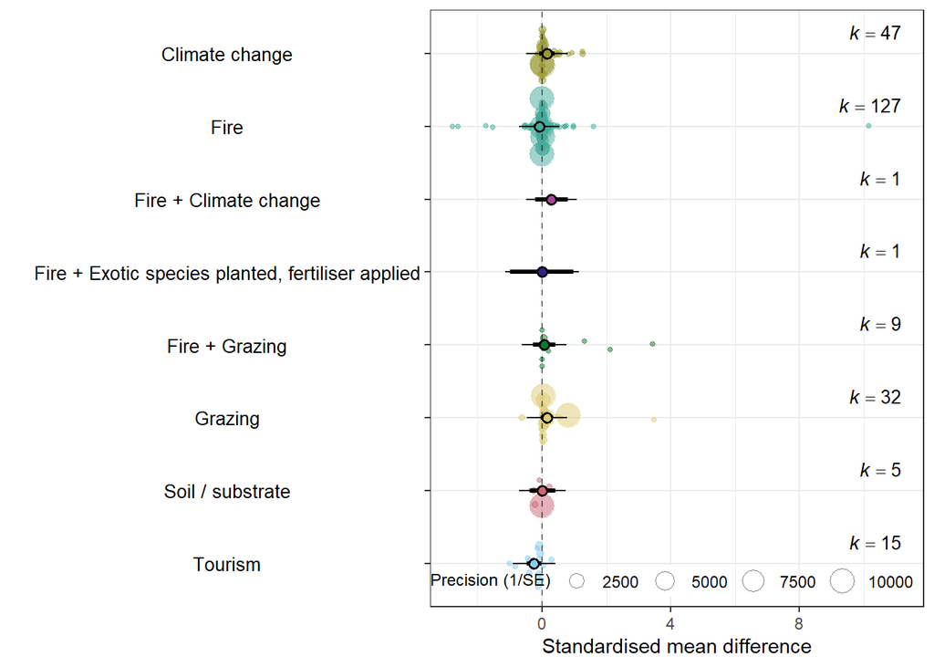

```r
model_results <- orchaRd::mod_results(m.final, mod = "Treatment_Thematic", at = NULL, group = "UniqueCode")
p1a <- orchaRd::orchard_plot(model_results, mod = "Treatment_Thematic", group = "UniqueCode", xlab = "Standardised mean difference", angle = 0, g = FALSE)
p1a
```

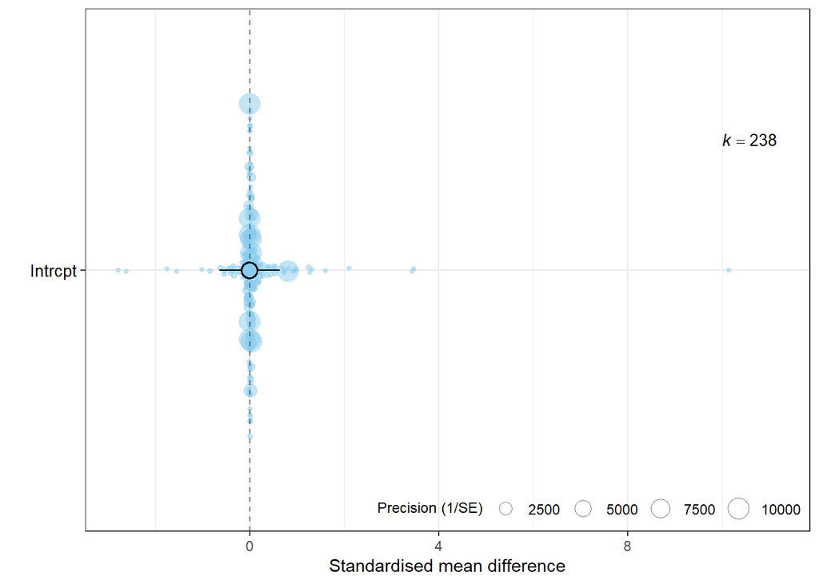

```r
p.all
```

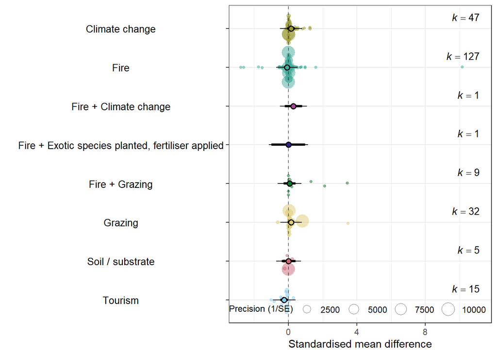

```r
p1a
```

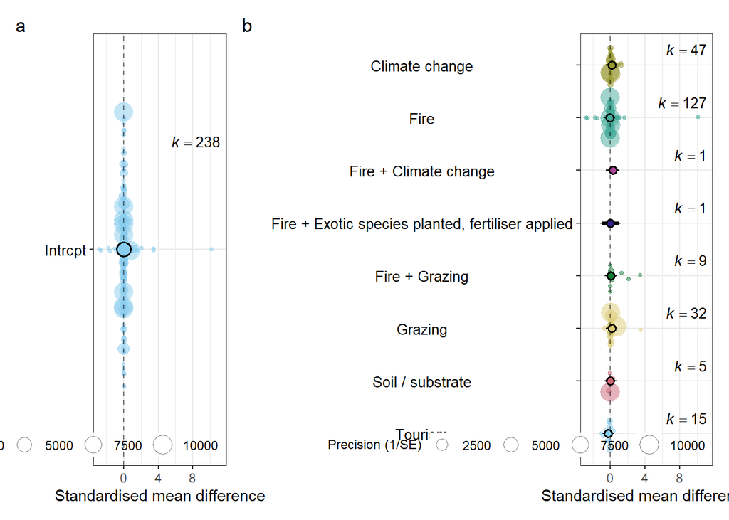

```r
(p.all | p1a) + plot_annotation(tag_levels = 'a')
```

#### 1.4.4. Ecosystem Model, and Driving Process - Ecosystem Model

```r
# Ecosystem Model
m.ES.cc <- rma.mv(TE ~ 1 + Aggregate.InitialES, # Moderator is the variable of interest
                   V = VCV,
                   data = df_ma,
                   sparse = TRUE,
                     random = ~ 1 | Study/UniqueCode)
AIC(m.ES.cc)
```

```
## [1] 201.3707
```

```r
summary(m.ES.cc)
```

```
##
## Multivariate Meta-Analysis Model (k = 238; method: REML)
##
##   logLik  Deviance       AIC       BIC      AICc
## -89.6854  179.3707  201.3707  239.1417  202.5873
##
## Variance Components:
##
##             estim    sqrt  nlvls  fixed            factor
## sigma^2.1  0.0760  0.2757     37     no             Study
## sigma^2.2  0.0343  0.1853    238     no  Study/UniqueCode
##
## Test of Moderators (coefficients 2:9):
## QM(df = 8) = 6.5965, p-val = 0.5807
##
## Model Results:
##
##                                                    estimate      se     zval
## intrcpt                                              0.2376  0.1376   1.7265
## Aggregate.InitialESMultiple                         -0.3604  0.1891  -1.9062
## Aggregate.InitialESHeathland (wet) / Grassland      -0.1993  0.2249  -0.8859
## Aggregate.InitialESHeathland (wet)                  -0.1929  0.2110  -0.9144
## Aggregate.InitialESHeathland (dry) / Grassland      -0.2235  0.1562  -1.4303
## Aggregate.InitialESHeathland (dry)                  -0.2328  0.1528  -1.5231
## Aggregate.InitialESGrassland (wet) / Herbfield      -0.3425  0.3666  -0.9342
## Aggregate.InitialESGrassland (dry) / Herbfield      -0.3369  0.1517  -2.2204
## Aggregate.InitialESCushion heathland / Fjaledmark   -0.3387  0.1727  -1.9611
##                                                      pval    ci.lb    ci.ub
## intrcpt                                            0.0843  -0.0321   0.5073  .
## Aggregate.InitialESMultiple                        0.0566  -0.7311   0.0102  .
## Aggregate.InitialESHeathland (wet) / Grassland     0.3757  -0.6401   0.2416
## Aggregate.InitialESHeathland (wet)                 0.3605  -0.6065   0.2206
## Aggregate.InitialESHeathland (dry) / Grassland     0.1526  -0.5297   0.0827
## Aggregate.InitialESHeathland (dry)                 0.1277  -0.5323   0.0668
## Aggregate.InitialESGrassland (wet) / Herbfield     0.3502  -1.0610   0.3761
## Aggregate.InitialESGrassland (dry) / Herbfield     0.0264  -0.6343  -0.0395  *
## Aggregate.InitialESCushion heathland / Fjaledmark  0.0499  -0.6771  -0.0002  *
##
## ---
## Signif. codes:  0 '***' 0.001 '**' 0.01 '*' 0.05 '.' 0.1 ' ' 1
```

```r
res <- m.ES.cc
W <- diag(1/res$vi)
X <- model.matrix(res)
P <- W - W %*% X %*% solve(t(X) %*% W %*% X) %*% t(X) %*% W
100 * sum(res$sigma2) / (sum(res$sigma2) + (res$k-res$p)/sum(diag(P))) # total I2
```

```
## [1] 99.99939
```

```r
100 * res$sigma2 / (sum(res$sigma2) + (res$k-res$p)/sum(diag(P))) # between and within I2
```

```
## [1] 68.88192 31.11747
```

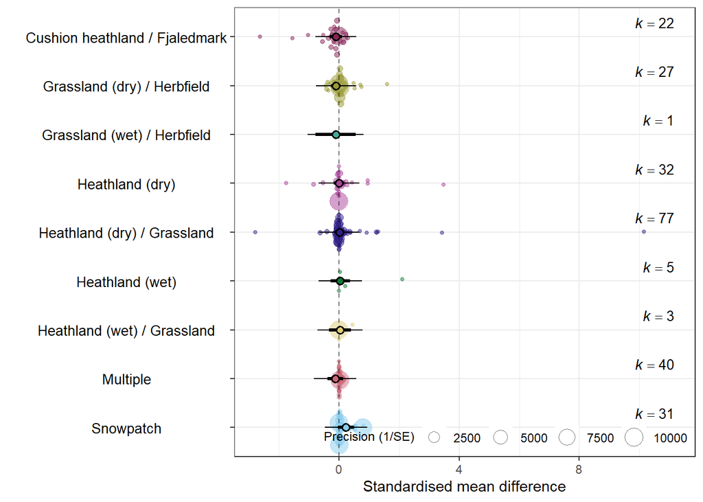

```r
# Visualising using forest plot
model_results <- orchaRd::mod_results(m.ES.cc, mod = "Aggregate.InitialES", at = NULL, group = "UniqueCode")
p1a <- orchaRd::orchard_plot(m.ES.cc, mod = "Aggregate.InitialES", group = "UniqueCode", xlab = "Standardised mean difference", angle = 0, g = FALSE)
p1a
```

```r
# Driving Process - Ecosystem Model
unique(df_ma$Aggregate.InitialES)
```

```
## [1] Heathland (dry)                Heathland (dry) / Grassland
## [3] Heathland (wet) / Grassland    Heathland (wet)
## [5] Cushion heathland / Fjaledmark Snowpatch
## [7] Grassland (dry) / Herbfield    Multiple
## [9] Grassland (wet) / Herbfield
## 9 Levels: Snowpatch Multiple Heathland (wet) / Grassland ... Cushion heathland / Fjaledmark
```

```r
m.ES.trt <- rma.mv(TE ~ 1 + Treatment_Thematic * Aggregate.InitialES, # Moderator is the variable of interest
                   V = VCV,
                   data = df_ma,
                   sparse = TRUE,
                     random = ~ 1 | Study/UniqueCode,
                  tdist = TRUE)
summary(m.ES.trt)
```

```
##
## Multivariate Meta-Analysis Model (k = 237; method: REML)
##
##   logLik  Deviance       AIC       BIC      AICc
## -76.2409  152.4817  214.4817  317.9454  225.7545
##
## Variance Components:
##
##             estim    sqrt  nlvls  fixed            factor
## sigma^2.1  0.0715  0.2674     36     no             Study
## sigma^2.2  0.0350  0.1870    237     no  Study/UniqueCode
##
## Test of Moderators (coefficients 2:29):
## F(df1 = 28, df2 = 208) = 0.9165, p-val = 0.5906
##
## Model Results:
##
##                                                                                  estimate
## intrcpt                                                                            0.1328
## Treatment_ThematicSoil / substrate                                                 0.0676
## Treatment_ThematicGrazing                                                          0.5426
## Treatment_ThematicFire + Grazing                                                   0.2979
## Treatment_ThematicFire + Exotic species planted, fertiliser applied               -0.0125
## Treatment_ThematicFire + Climate change                                            0.3170
## Treatment_ThematicFire                                                            -0.0997
## Treatment_ThematicClimate change                                                  -0.0666
## Aggregate.InitialESMultiple                                                       -0.1444
## Aggregate.InitialESHeathland (wet) / Grassland                                    -0.1455
## Aggregate.InitialESHeathland (wet)                                                -0.0350
## Aggregate.InitialESHeathland (dry) / Grassland                                    -0.1203
## Aggregate.InitialESHeathland (dry)                                                -0.5820
## Aggregate.InitialESGrassland (wet) / Herbfield                                    -0.1354
## Aggregate.InitialESGrassland (dry) / Herbfield                                    -0.4772
## Aggregate.InitialESCushion heathland / Fjaledmark                                 -0.1912
## Treatment_ThematicGrazing:Aggregate.InitialESMultiple                             -0.5291
## Treatment_ThematicGrazing:Aggregate.InitialESHeathland (wet)                      -0.6404
## Treatment_ThematicFire + Grazing:Aggregate.InitialESHeathland (wet)               -0.0675
## Treatment_ThematicGrazing:Aggregate.InitialESHeathland (dry) / Grassland          -0.5890
## Treatment_ThematicFire + Grazing:Aggregate.InitialESHeathland (dry) / Grassland   -0.0140
## Treatment_ThematicFire:Aggregate.InitialESHeathland (dry) / Grassland              0.1096
```

[output cut: 205 more lines]

```
## Treatment_ThematicGrazing:Aggregate.InitialESHeathland (wet)
## Treatment_ThematicFire + Grazing:Aggregate.InitialESHeathland (wet)
## Treatment_ThematicGrazing:Aggregate.InitialESHeathland (dry) / Grassland
## Treatment_ThematicFire + Grazing:Aggregate.InitialESHeathland (dry) / Grassland
## Treatment_ThematicFire:Aggregate.InitialESHeathland (dry) / Grassland
## Treatment_ThematicClimate change:Aggregate.InitialESHeathland (dry) / Grassland
## Treatment_ThematicGrazing:Aggregate.InitialESHeathland (dry)
## Treatment_ThematicFire + Grazing:Aggregate.InitialESHeathland (dry)
## Treatment_ThematicFire:Aggregate.InitialESHeathland (dry)
## Treatment_ThematicGrazing:Aggregate.InitialESGrassland (dry) / Herbfield
## Treatment_ThematicFire:Aggregate.InitialESGrassland (dry) / Herbfield
## Treatment_ThematicGrazing:Aggregate.InitialESCushion heathland / Fjaledmark
##
## ---
## Signif. codes:  0 '***' 0.001 '**' 0.01 '*' 0.05 '.' 0.1 ' ' 1
```

```r
AIC(m.ES.trt)
```

```
## [1] 214.4817
```

```r
res <- m.ES.trt
W <- diag(1/res$vi)
X <- model.matrix(res)
P <- W - W %*% X %*% solve(t(X) %*% W %*% X) %*% t(X) %*% W
100 * sum(res$sigma2) / (sum(res$sigma2) + (res$k-res$p)/sum(diag(P))) # total I2
```

```
## [1] 99.99852
```

```r
100 * res$sigma2 / (sum(res$sigma2) + (res$k-res$p)/sum(diag(P))) # between and within I2
```

```
## [1] 67.15083 32.84769
```

```r
100 - (62.61131+37.38824) # I2 due to sampling error
```

```
## [1] 0.00045
```

#### 1.4.5. Population Model, and Driving Process - Population Model

```r
# Population Model
m.pop <- rma.mv(TE ~ 1 + Response.Level, # Moderator is the variable of interest
                   V = VCV,
                   data = df_ma,
                   sparse = TRUE,
                     random = ~ 1 | Study/UniqueCode)
summary(m.pop)
```

```
##
## Multivariate Meta-Analysis Model (k = 238; method: REML)
##
##   logLik  Deviance       AIC       BIC      AICc
## -92.8562  185.7125  195.7125  213.0104  195.9745
##
## Variance Components:
##
##             estim    sqrt  nlvls  fixed            factor
## sigma^2.1  0.0671  0.2591     37     no             Study
## sigma^2.2  0.0344  0.1854    238     no  Study/UniqueCode
##
## Test of Moderators (coefficients 2:3):
## QM(df = 2) = 2.0427, p-val = 0.3601
##
## Model Results:
##
##                                      estimate      se     zval    pval    ci.lb
## intrcpt                               -0.0452  0.0617  -0.7335  0.4632  -0.1661
## Response.LevelSpecies                  0.0788  0.0553   1.4266  0.1537  -0.0295
## Response.LevelCommunity / Ecosystem    0.0407  0.0821   0.4954  0.6203  -0.1202
##                                       ci.ub
## intrcpt                              0.0756
## Response.LevelSpecies                0.1872
## Response.LevelCommunity / Ecosystem  0.2016
##
## ---
## Signif. codes:  0 '***' 0.001 '**' 0.01 '*' 0.05 '.' 0.1 ' ' 1
```

```r
AIC(m.pop )
```

```
## [1] 195.7125
```

```r
res <- m.pop
W <- diag(1/res$vi)
X <- model.matrix(res)
P <- W - W %*% X %*% solve(t(X) %*% W %*% X) %*% t(X) %*% W
100 * sum(res$sigma2) / (sum(res$sigma2) + (res$k-res$p)/sum(diag(P))) # total I2
```

```
## [1] 99.99964
```

```r
100 * res$sigma2 / (sum(res$sigma2) + (res$k-res$p)/sum(diag(P))) # between and within I2
```

```
## [1] 66.13682 33.86282
```

```r
100 - ( 67.72084 + 32.27882) # I2 due to sampling error
```

```
## [1] 0.00034
```

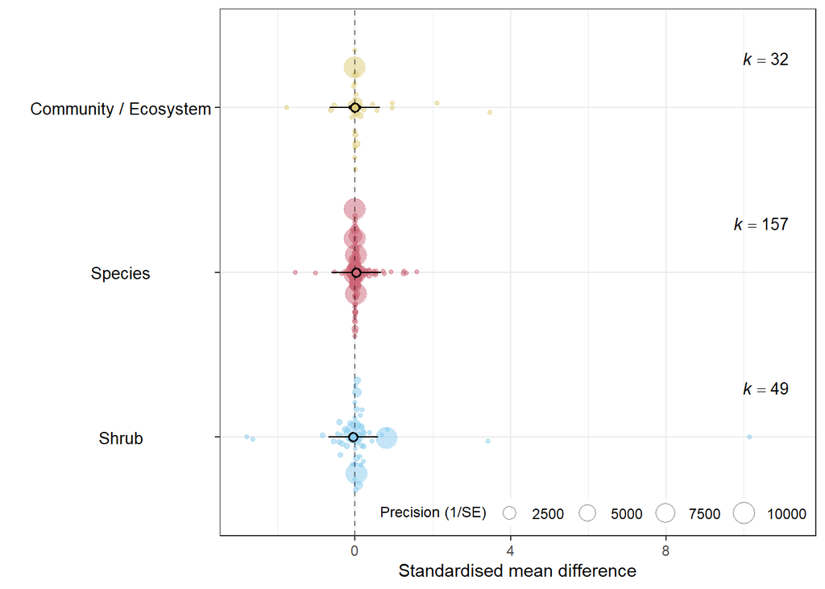

```r
model_results <- orchaRd::mod_results(m.pop, mod = "Response.Level", at = NULL, group = "UniqueCode")
p1a <- orchaRd::orchard_plot(m.pop, mod = "Response.Level", group = "UniqueCode", xlab = "Standardised mean difference", angle = 0, g = FALSE)
p1a
```

```r
# Driving Process - Population Model
unique(df_ma$Aggregate.InitialES)
```

```
## [1] Heathland (dry)                Heathland (dry) / Grassland
## [3] Heathland (wet) / Grassland    Heathland (wet)
## [5] Cushion heathland / Fjaledmark Snowpatch
## [7] Grassland (dry) / Herbfield    Multiple
## [9] Grassland (wet) / Herbfield
## 9 Levels: Snowpatch Multiple Heathland (wet) / Grassland ... Cushion heathland / Fjaledmark
```

```r
m.ES.trt <- rma.mv(TE ~ 1 + Treatment_Thematic * Response.Level, # Moderator is the variable of interest
                   V = VCV,
                   data = df_ma,
                   sparse = TRUE,
                     random = ~ 1 | Study/UniqueCode,
                  tdist = TRUE)
summary(m.ES.trt)
```

```
##
## Multivariate Meta-Analysis Model (k = 237; method: REML)
##
##   logLik  Deviance       AIC       BIC      AICc
## -78.0703  156.1406  198.1406  269.2150  202.8549
##
## Variance Components:
##
##             estim    sqrt  nlvls  fixed            factor
## sigma^2.1  0.1008  0.3175     36     no             Study
## sigma^2.2  0.0318  0.1783    237     no  Study/UniqueCode
##
## Test of Moderators (coefficients 2:19):
## F(df1 = 18, df2 = 218) = 1.2350, p-val = 0.2350
##
## Model Results:
##
##                                                                         estimate
## intrcpt                                                                  -0.3729
## Treatment_ThematicSoil / substrate                                        0.2155
## Treatment_ThematicGrazing                                                 0.5396
## Treatment_ThematicFire + Grazing                                          0.5527
## Treatment_ThematicFire + Exotic species planted, fertiliser applied       0.3729
## Treatment_ThematicFire + Climate change                                   0.5925
## Treatment_ThematicFire                                                    0.2322
## Treatment_ThematicClimate change                                          0.4212
## Response.LevelSpecies                                                     0.3133
## Response.LevelCommunity / Ecosystem                                       0.6509
## Treatment_ThematicGrazing:Response.LevelSpecies                          -0.2123
## Treatment_ThematicFire + Grazing:Response.LevelSpecies                   -0.7622
## Treatment_ThematicFire:Response.LevelSpecies                             -0.2401
## Treatment_ThematicClimate change:Response.LevelSpecies                   -0.1146
## Treatment_ThematicSoil / substrate:Response.LevelCommunity / Ecosystem   -0.2696
## Treatment_ThematicGrazing:Response.LevelCommunity / Ecosystem            -0.7232
## Treatment_ThematicFire + Grazing:Response.LevelCommunity / Ecosystem     -0.6440
## Treatment_ThematicFire:Response.LevelCommunity / Ecosystem               -0.6641
## Treatment_ThematicClimate change:Response.LevelCommunity / Ecosystem     -0.6781
##                                                                             se
## intrcpt                                                                 0.1632
## Treatment_ThematicSoil / substrate                                      0.3716
```

[output cut: 125 more lines]

```
## Treatment_ThematicClimate change
## Response.LevelSpecies
## Response.LevelCommunity / Ecosystem                                     **
## Treatment_ThematicGrazing:Response.LevelSpecies
## Treatment_ThematicFire + Grazing:Response.LevelSpecies
## Treatment_ThematicFire:Response.LevelSpecies
## Treatment_ThematicClimate change:Response.LevelSpecies
## Treatment_ThematicSoil / substrate:Response.LevelCommunity / Ecosystem
## Treatment_ThematicGrazing:Response.LevelCommunity / Ecosystem           **
## Treatment_ThematicFire + Grazing:Response.LevelCommunity / Ecosystem
## Treatment_ThematicFire:Response.LevelCommunity / Ecosystem               *
## Treatment_ThematicClimate change:Response.LevelCommunity / Ecosystem
##
## ---
## Signif. codes:  0 '***' 0.001 '**' 0.01 '*' 0.05 '.' 0.1 ' ' 1
```

```r
AIC(m.ES.trt)
```

```
## [1] 198.1406
```

```r
res <- m.ES.trt
W <- diag(1/res$vi)
X <- model.matrix(res)
P <- W - W %*% X %*% solve(t(X) %*% W %*% X) %*% t(X) %*% W
100 * sum(res$sigma2) / (sum(res$sigma2) + (res$k-res$p)/sum(diag(P))) # total I2
```

```
## [1] 99.99962
```

```r
100 * res$sigma2 / (sum(res$sigma2) + (res$k-res$p)/sum(diag(P))) # between and within I2
```

```
## [1] 76.02429 23.97533
```

```r
100 - (62.61131+37.38824) # I2 due to sampling error
```

```
## [1] 0.00045
```

#### 1.4.6. Assessment of publication bias in Driving Process Model, Ecosystem Model, Population Model, Driving Process - Population Model and Driving Process - Ecosystem Model.

Note the following references for Egger’s Test from Harrer et al., 2002: https://osf.io/vqp8u and https://doi.org/10.1037/met0000300. The method below adapts the meta-regression to use the the SE of SMD as the moderator.

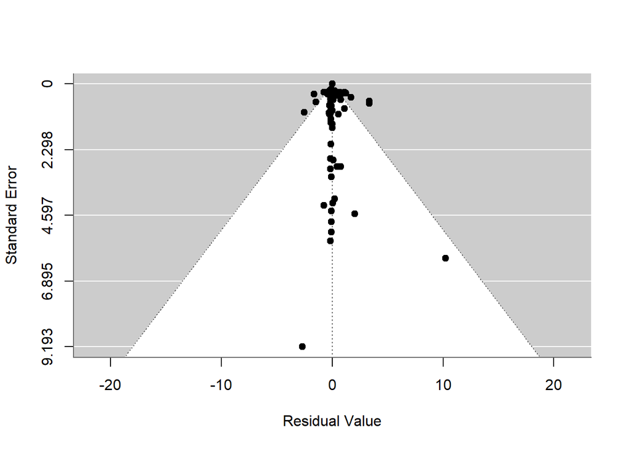

```r
# Funnel plot...
meta::funnel(m.final)
```

```r
# Egger Test
# This adapts the meta-regression to use the the SE of SMD as the moderator
# Ref: https://osf.io/vqp8u and https://doi.org/10.1037/met0000300
m3.eggertest <- rma.mv(yi = TE,
                     V = se.TE^2,
                     slab = Study,
                     data = df_ma,
                     random = ~ 1 | Study/UniqueCode, # ~ 1 | cluster/effects_within_cluster.
                     test = "t",
                     method = "REML",
             mods = ~ se.TE, # this is the egger test, using the SE of SMD as the moderator - this is the measure of precision.
             control = list(optimizer = "optim")) # Change omptimiser from nlminb to optim, note that by default, it fits a fixed effects model within a cluster, and random between clusters
coef_test(m3.eggertest, vcov = "CR2") # cluster-robust standard errors for the RVE-based test
```

```
##    Coef. Estimate     SE t-stat d.f. (Satt) p-val (Satt) Sig.
##  intrcpt   0.0258 0.0632  0.408        29.6        0.686
##    se.TE   0.2472 0.2350  1.052        12.7        0.313
```

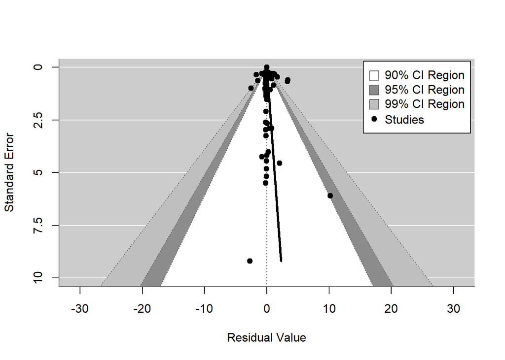

```r
meta::funnel(m.final, level=c(90, 95, 99), shade=c("white", "gray55", "gray75"), digits=3L, ylim=c(0,10), legend=list(show="cis"))
se <- seq(0, max(sqrt(df_ma$se.TE)), length=100)
lines(coef(m3.eggertest)[1] + coef(m3.eggertest)[2]* se, se, lwd=3)
```

```r
summary(m3.eggertest) # intercept is the bias estimate, the t-stat, df and p-value show whether aysmetry is significant.
```

```
##
## Multivariate Meta-Analysis Model (k = 238; method: REML)
##
##    logLik   Deviance        AIC        BIC       AICc
## -164.0153   328.0306   336.0306   349.8859   336.2037
##
## Variance Components:
##
##             estim    sqrt  nlvls  fixed            factor
## sigma^2.1  0.1091  0.3303     37     no             Study
## sigma^2.2  0.0747  0.2733    238     no  Study/UniqueCode
##
## Test for Residual Heterogeneity:
## QE(df = 236) = 5713644207154848.0000, p-val < .0001
##
## Test of Moderators (coefficient 2):
## F(df1 = 1, df2 = 236) = 2.0460, p-val = 0.1539
##
## Model Results:
##
##          estimate      se    tval   df    pval    ci.lb   ci.ub
## intrcpt    0.0258  0.0669  0.3856  236  0.7002  -0.1060  0.1575
## se.TE      0.2472  0.1728  1.4304  236  0.1539  -0.0933  0.5877
##
## ---
## Signif. codes:  0 '***' 0.001 '**' 0.01 '*' 0.05 '.' 0.1 ' ' 1
```

#### 1.4.7. Sensitivity analysis of Driving Process Model, Ecosystem Model, Population Model, Driving Process - Population Model and Driving Process - Ecosystem Model.

```r
# CHE RVE rho = 0.29
VCV <- vcalc(vi = se.TE,
             cluster = Study,
             rho = 0.29,
             obs = TE,
             data = df_ma)
# Population level
m.sa <- rma.mv(TE ~ 1 +  Response.Level, # Moderator is the variable of interest
                   V = VCV,
                   data = df_ma,
                   sparse = TRUE,
                     random = ~ 1 | Study/UniqueCode)
summary(m.sa) # interested in the QM (showing significant moderator category differences
```

```
##
## Multivariate Meta-Analysis Model (k = 238; method: REML)
##
##   logLik  Deviance       AIC       BIC      AICc
## -92.8562  185.7125  195.7125  213.0104  195.9745
##
## Variance Components:
##
##             estim    sqrt  nlvls  fixed            factor
## sigma^2.1  0.0671  0.2591     37     no             Study
## sigma^2.2  0.0344  0.1854    238     no  Study/UniqueCode
##
## Test of Moderators (coefficients 2:3):
## QM(df = 2) = 2.0427, p-val = 0.3601
##
## Model Results:
##
##                                      estimate      se     zval    pval    ci.lb
## intrcpt                               -0.0452  0.0617  -0.7335  0.4632  -0.1661
## Response.LevelSpecies                  0.0788  0.0553   1.4266  0.1537  -0.0295
## Response.LevelCommunity / Ecosystem    0.0407  0.0821   0.4954  0.6203  -0.1202
##                                       ci.ub
## intrcpt                              0.0756
## Response.LevelSpecies                0.1872
## Response.LevelCommunity / Ecosystem  0.2016
##
## ---
## Signif. codes:  0 '***' 0.001 '**' 0.01 '*' 0.05 '.' 0.1 ' ' 1
```

```r
# Test statistic
m.sa <- rma.mv(TE ~ 1 +  d.stat2, # Moderator is the variable of interest
                   V = VCV,
                   data = df_ma,
                   sparse = TRUE,
                     random = ~ 1 | Study/UniqueCode)
summary(m.sa) # interested in the QM (showing significant moderator category differences
```

```
##
## Multivariate Meta-Analysis Model (k = 238; method: REML)
##
##   logLik  Deviance       AIC       BIC      AICc
## -92.4397  184.8795  194.8795  212.1774  195.1415
##
## Variance Components:
##
##             estim    sqrt  nlvls  fixed            factor
## sigma^2.1  0.0591  0.2431     37     no             Study
## sigma^2.2  0.0357  0.1889    238     no  Study/UniqueCode
##
## Test of Moderators (coefficients 2:3):
## QM(df = 2) = 2.3797, p-val = 0.3043
##
## Model Results:
##
##                 estimate      se     zval    pval    ci.lb   ci.ub
## intrcpt          -0.0255  0.0654  -0.3894  0.6970  -0.1537  0.1028
## d.stat2d(IGPP)    0.0646  0.0735   0.8789  0.3795  -0.0794  0.2086
## d.stat2d(RM)     -0.0170  0.0851  -0.2000  0.8415  -0.1838  0.1498
##
## ---
## Signif. codes:  0 '***' 0.001 '**' 0.01 '*' 0.05 '.' 0.1 ' ' 1
```

```r
# Study design
m.sa <- rma.mv(TE ~ 1 +  `Study design`, # Moderator is the variable of interest
                   V = VCV,
                   data = df_ma,
                   sparse = TRUE,
                     random = ~ 1 | Study/UniqueCode)
summary(m.sa) # interested in the QM (showing significant moderator category differences
```

```
##
## Multivariate Meta-Analysis Model (k = 238; method: REML)
##
##   logLik  Deviance       AIC       BIC      AICc
## -88.9282  177.8564  187.8564  205.1543  188.1184
##
## Variance Components:
##
##             estim    sqrt  nlvls  fixed            factor
## sigma^2.1  0.0383  0.1956     37     no             Study
## sigma^2.2  0.0353  0.1879    238     no  Study/UniqueCode
##
## Test of Moderators (coefficients 2:3):
## QM(df = 2) = 11.4235, p-val = 0.0033
##
## Model Results:
##
##                     estimate      se     zval    pval    ci.lb    ci.ub
## intrcpt               0.0785  0.0618   1.2713  0.2036  -0.0426   0.1996
## `Study design`BACI    0.0431  0.0503   0.8574  0.3912  -0.0555   0.1417
## `Study design`CI     -0.2460  0.0885  -2.7783  0.0055  -0.4195  -0.0724  **
##
## ---
## Signif. codes:  0 '***' 0.001 '**' 0.01 '*' 0.05 '.' 0.1 ' ' 1
```

```r
# Ecosystem type
m.sa <- rma.mv(TE ~ 1 +  Aggregate.InitialES, # Moderator is the variable of interest
                   V = VCV,
                   data = df_ma,
                   sparse = TRUE,
                     random = ~ 1 | Study/UniqueCode)
summary(m.sa) # interested in the QM (showing significant moderator category differences
```

```
##
## Multivariate Meta-Analysis Model (k = 238; method: REML)
##
##   logLik  Deviance       AIC       BIC      AICc
## -89.6854  179.3707  201.3707  239.1417  202.5873
##
## Variance Components:
##
##             estim    sqrt  nlvls  fixed            factor
## sigma^2.1  0.0760  0.2757     37     no             Study
## sigma^2.2  0.0343  0.1853    238     no  Study/UniqueCode
##
## Test of Moderators (coefficients 2:9):
## QM(df = 8) = 6.5965, p-val = 0.5807
##
## Model Results:
##
##                                                    estimate      se     zval
## intrcpt                                              0.2376  0.1376   1.7265
## Aggregate.InitialESMultiple                         -0.3604  0.1891  -1.9062
## Aggregate.InitialESHeathland (wet) / Grassland      -0.1993  0.2249  -0.8859
## Aggregate.InitialESHeathland (wet)                  -0.1929  0.2110  -0.9144
## Aggregate.InitialESHeathland (dry) / Grassland      -0.2235  0.1562  -1.4303
## Aggregate.InitialESHeathland (dry)                  -0.2328  0.1528  -1.5231
## Aggregate.InitialESGrassland (wet) / Herbfield      -0.3425  0.3666  -0.9342
## Aggregate.InitialESGrassland (dry) / Herbfield      -0.3369  0.1517  -2.2204
## Aggregate.InitialESCushion heathland / Fjaledmark   -0.3387  0.1727  -1.9611
##                                                      pval    ci.lb    ci.ub
## intrcpt                                            0.0843  -0.0321   0.5073  .
## Aggregate.InitialESMultiple                        0.0566  -0.7311   0.0102  .
## Aggregate.InitialESHeathland (wet) / Grassland     0.3757  -0.6401   0.2416
## Aggregate.InitialESHeathland (wet)                 0.3605  -0.6065   0.2206
## Aggregate.InitialESHeathland (dry) / Grassland     0.1526  -0.5297   0.0827
## Aggregate.InitialESHeathland (dry)                 0.1277  -0.5323   0.0668
## Aggregate.InitialESGrassland (wet) / Herbfield     0.3502  -1.0610   0.3761
## Aggregate.InitialESGrassland (dry) / Herbfield     0.0264  -0.6343  -0.0395  *
## Aggregate.InitialESCushion heathland / Fjaledmark  0.0499  -0.6771  -0.0002  *
##
## ---
## Signif. codes:  0 '***' 0.001 '**' 0.01 '*' 0.05 '.' 0.1 ' ' 1
```

```r
# Study region
m.sa <- rma.mv(TE ~ 1 +  site.map, # Moderator is the variable of interest
                   V = VCV,
                   data = df_ma,
                   sparse = TRUE,
                     random = ~ 1 | Study/UniqueCode)
summary(m.sa) # interested in the QM (showing significant moderator category differences
```

```
##
## Multivariate Meta-Analysis Model (k = 238; method: REML)
##
##   logLik  Deviance       AIC       BIC      AICc
## -81.1866  162.3733  190.3733  238.2608  192.3638
##
## Variance Components:
##
##             estim    sqrt  nlvls  fixed            factor
## sigma^2.1  0.0856  0.2926     37     no             Study
## sigma^2.2  0.0356  0.1887    238     no  Study/UniqueCode
##
## Test of Moderators (coefficients 2:12):
## QM(df = 11) = 6.1379, p-val = 0.8640
##
## Model Results:
##
##                                        estimate      se     zval    pval
## intrcpt                                 -0.0088  0.0873  -0.1013  0.9193
## site.mapCentral East Plateau             0.1156  0.1707   0.6774  0.4982
## site.mapGuthega                          0.0895  0.2059   0.4346  0.6638
## site.mapHartz Mountains National Park   -0.1487  0.3242  -0.4585  0.6466
## site.mapHolmes Plains                    9.7861  5.8450   1.6743  0.0941
## site.mapKiandra                         -2.7794  9.1953  -0.3023  0.7625
## site.mapMiddlesex Plains                 0.0912  0.2635   0.3462  0.7292
## site.mapMt Bogong                        0.0213  0.3612   0.0590  0.9529
## site.mapMt Kosciuszko region            -0.1824  0.1669  -1.0929  0.2744
## site.mapMt Wellington                    0.2052  0.3254   0.6308  0.5282
## site.mapSummits across Tasmania         -0.0610  0.9580  -0.0636  0.9493
## site.mapWellington Plains                0.1079  0.3565   0.3026  0.7622
##                                           ci.lb    ci.ub
## intrcpt                                 -0.1799   0.1622
## site.mapCentral East Plateau            -0.2189   0.4502
## site.mapGuthega                         -0.3141   0.4930
## site.mapHartz Mountains National Park   -0.7842   0.4868
## site.mapHolmes Plains                   -1.6698  21.2421  .
## site.mapKiandra                        -20.8019  15.2432
## site.mapMiddlesex Plains                -0.4253   0.6078
## site.mapMt Bogong                       -0.6866   0.7292
## site.mapMt Kosciuszko region            -0.5094   0.1447
## site.mapMt Wellington                   -0.4325   0.8430
## site.mapSummits across Tasmania         -1.9387   1.8168
## site.mapWellington Plains               -0.5909   0.8067
##
## ---
## Signif. codes:  0 '***' 0.001 '**' 0.01 '*' 0.05 '.' 0.1 ' ' 1
```

```r
# lower elevation
m.sa <- rma.mv(TE ~ 1 +  elev.lower.sa, # Moderator is the variable of interest
                   V = VCV,
                   data = df_ma,
                   sparse = TRUE,
                     random = ~ 1 | Study/UniqueCode)
summary(m.sa) # interested in the QM (showing significant moderator category differences
```

```
##
## Multivariate Meta-Analysis Model (k = 238; method: REML)
##
##   logLik  Deviance       AIC       BIC      AICc
## -91.8762  183.7523  195.7523  216.4842  196.1224
##
## Variance Components:
##
##             estim    sqrt  nlvls  fixed            factor
## sigma^2.1  0.0718  0.2680     37     no             Study
## sigma^2.2  0.0353  0.1879    238     no  Study/UniqueCode
##
## Test of Moderators (coefficients 2:4):
## QM(df = 3) = 1.0952, p-val = 0.7782
##
## Model Results:
##
##                           estimate      se     zval    pval    ci.lb   ci.ub
## intrcpt                     0.0406  0.1777   0.2282  0.8195  -0.3078  0.3889
## elev.lower.sa> 1600        -0.1169  0.1982  -0.5898  0.5553  -0.5054  0.2716
## elev.lower.sa1200 - 1600    0.0041  0.1908   0.0215  0.9828  -0.3698  0.3780
## elev.lower.sa800 - 1200    -0.0085  0.1818  -0.0468  0.9627  -0.3649  0.3479
##
## ---
## Signif. codes:  0 '***' 0.001 '**' 0.01 '*' 0.05 '.' 0.1 ' ' 1
```

```r
# upper elevation
m.sa <- rma.mv(TE ~ 1 +  elev.upper.sa, # Moderator is the variable of interest
                   V = VCV,
                   data = df_ma,
                   sparse = TRUE,
                     random = ~ 1 | Study/UniqueCode)
summary(m.sa) # interested in the QM (showing significant moderator category differences
```

```
##
## Multivariate Meta-Analysis Model (k = 238; method: REML)
##
##   logLik  Deviance       AIC       BIC      AICc
## -92.5544  185.1087  197.1087  217.8407  197.4788
##
## Variance Components:
##
##             estim    sqrt  nlvls  fixed            factor
## sigma^2.1  0.0798  0.2824     37     no             Study
## sigma^2.2  0.0346  0.1861    238     no  Study/UniqueCode
##
## Test of Moderators (coefficients 2:4):
## QM(df = 3) = 0.7252, p-val = 0.8673
##
## Model Results:
##
##                           estimate      se     zval    pval    ci.lb   ci.ub
## intrcpt                     0.0685  0.2431   0.2816  0.7783  -0.4080  0.5449
## elev.upper.sa> 1600        -0.0791  0.2525  -0.3132  0.7541  -0.5740  0.4158
## elev.upper.sa1200 - 1600   -0.1422  0.2717  -0.5232  0.6008  -0.6747  0.3904
## elev.upper.sa800 - 1200     0.0153  0.2269   0.0676  0.9461  -0.4295  0.4602
##
## ---
## Signif. codes:  0 '***' 0.001 '**' 0.01 '*' 0.05 '.' 0.1 ' ' 1
```

```r
# Timespan
range(df_ma$se.TE)
```

```
## [1]  0.00000001 84.42526149
```

```r
x <- lm(TE ~ timespan, data = df_ma)
summary(x)$r.squared
```

```
## [1] 0.01161141
```

```r
p1 <- df_ma %>% filter (`Study design` != "CI") %>%
  ggplot(aes(x = as.numeric(timespan), y = as.numeric(TE))) +
  geom_point(aes(size = se.TE), alpha = 0.5) +
  theme_classic() +
  geom_smooth(method = lm) +
  ylab("Standardised mean difference") +
  xlab("Study timespan (years)") +
  scale_alpha(name = "Standard error, SMD")
m.sa <- rma.mv(TE ~ 1 +  sa.timespan, # Moderator is the variable of interest
                   V = VCV,
                   data = df_ma,
                   sparse = TRUE,
                     random = ~ 1 | Study/UniqueCode)
summary(m.sa) # interested in the QM (showing significant moderator category differences
```

```
##
## Multivariate Meta-Analysis Model (k = 238; method: REML)
##
##   logLik  Deviance       AIC       BIC      AICc
## -90.2646  180.5292  190.5292  207.8271  190.7912
##
## Variance Components:
##
##             estim    sqrt  nlvls  fixed            factor
## sigma^2.1  0.0407  0.2018     37     no             Study
## sigma^2.2  0.0360  0.1897    238     no  Study/UniqueCode
##
## Test of Moderators (coefficients 2:3):
## QM(df = 2) = 8.2314, p-val = 0.0163
##
## Model Results:
##
##                           estimate      se     zval    pval    ci.lb    ci.ub
## intrcpt                     0.0822  0.0696   1.1823  0.2371  -0.0541   0.2186
## sa.timespan1 - 20 years     0.0092  0.0652   0.1406  0.8882  -0.1186   0.1370
## sa.timespanNo time frame   -0.2120  0.0891  -2.3791  0.0174  -0.3867  -0.0374
##
## intrcpt
## sa.timespan1 - 20 years
## sa.timespanNo time frame  *
##
## ---
## Signif. codes:  0 '***' 0.001 '**' 0.01 '*' 0.05 '.' 0.1 ' ' 1
```